# Objectif

- Extraire des infos intéressantes type :
  - prix min, moyen et max
  - durée min, max, moyenne par trajet
- Différence de prix moyen et durée selon le train, le bus et le covoit selon la distance du trajet

  Par exemple (0-200km, 201-800km, 800-2000km, 2000+km)
- Le plus d’infos bonus !

  Comme par exemple :

  *Graphes, prédictions de prix, rapport des soucis relevés dans les données, visualisation interactive, sourcing & utilisation de données externes pertinentes, utilisation d’API externes*

# Les données

stations.csv

providers.csv

cities.csv

ticket_data.csv

- *ticket_data.csv* : Contenant un historique de ticket (une ligne => une proposition de ticket sur tictactrip)
- *cities.csv* les villes desservies par tictactrip (lien grâce aux colonnes o_city (origin_city), d_city (destination_city) de ticket_data)
- *stations.csv* les stations desservies par tictactrip (lien via o_station, d_station de ticket_data)
- *providers.csv* infos sur les différents providers (lien via company de ticket_data)Un provider est une "sous-compagnie". Par exemple TGV et TER sont deux providers de VSC (voyages-sncf).

```python
#!pip install haversine
#!pip install gmaps;
#!jupyter nbextension enable --py gmaps
#!jupyter nbextension enable --py widgetsnbextension
```

```python
import pandas as pd
import numpy as np

import gmaps

from datetime import datetime as dt
from haversine import haversine, Unit

import matplotlib.pyplot as plt
import seaborn as sns

import re
%matplotlib inline
```

```python
stations = pd.DataFrame(pd.read_csv("stations.csv"))
providers = pd.DataFrame(pd.read_csv("providers.csv"))
cities = pd.DataFrame(pd.read_csv("cities.csv"))
ticket_data = pd.DataFrame(pd.read_csv("ticket_data.csv"))
```

# Analyse Descriptive

## Dataset : stations

```python
stations.shape
```

```
(11035, 4)
```

```python
stations.isna().sum()
```

```
id             0
unique_name    0
latitude       0
longitude      0
dtype: int64
```

```python
stations.head(10)
```

|  | id | unique_name | latitude | longitude |
| --- | --- | --- | --- | --- |
| 0 | 1 | Aalen (Stuttgarter Straße) | 48.835296 | 10.092956 |
| 1 | 2 | Aéroport Bordeaux-Mérignac | 44.830226 | -0.700883 |
| 2 | 3 | Aéroport CDG | 49.009900 | 2.559310 |
| 3 | 4 | Aéroport de Berlin-Schönefeld | 52.389446 | 13.520345 |
| 4 | 5 | Aéroport de Dresden | 51.123604 | 13.764737 |
| 5 | 6 | Aéroport de Genève | 46.230121 | 6.109288 |
| 6 | 7 | Aéroport de Paris Beauvais-Tillé | 49.462541 | 2.116935 |
| 7 | 8 | Aéroport de Prague (bus station) | 50.107533 | 14.269309 |
| 8 | 9 | Aéroport de Tegel | 52.553760 | 13.292310 |
| 9 | 10 | Aéroport Marco Polo | 45.505432 | 12.338465 |

```python
stations.describe()
```

|  | id | latitude | longitude |
| --- | --- | --- | --- |
| count | 11035.000000 | 11035.000000 | 11035.000000 |
| mean | 5518.026914 | 47.526678 | 7.580807 |
| std | 3185.719813 | 3.953972 | 63.655681 |
| min | 1.000000 | -22.355790 | -22.625538 |
| 25% | 2759.500000 | 44.896447 | 1.358655 |
| 50% | 5518.000000 | 47.759670 | 5.824010 |
| 75% | 8276.500000 | 50.349956 | 12.166133 |
| max | 11036.000000 | 64.137571 | 6645.000000 |

```python
stations[stations["longitude"] == 6645]
stations = stations.drop([161]).reset_index(drop=True)
```

```python
stations.describe()
```

|  | id | latitude | longitude |
| --- | --- | --- | --- |
| count | 11034.000000 | 11034.000000 | 11034.000000 |
| mean | 5518.512326 | 47.526826 | 6.979265 |
| std | 3185.456049 | 3.954120 | 7.681139 |
| min | 1.000000 | -22.355790 | -22.625538 |
| 25% | 2760.250000 | 44.896169 | 1.358478 |
| 50% | 5518.500000 | 47.759885 | 5.822455 |
| 75% | 8276.750000 | 50.350213 | 12.163364 |
| max | 11036.000000 | 64.137571 | 44.009200 |

## Dataset : cities

```python
cities.shape
```

```
(8040, 6)
```

```python
cities.head(10)
```

|  | id | local_name | unique_name | latitude | longitude | population |
| --- | --- | --- | --- | --- | --- | --- |
| 0 | 5159 | Padua, Veneto, Italia | padua | 45.406435 | 11.876761 | 209678.0 |
| 1 | 76 | Barcelona, Cataluña, España | barcelona | 41.385064 | 2.173404 | 1611822.0 |
| 2 | 81 | Basel, Basel-Stadt, Schweiz | basel | 47.593437 | 7.619812 | NaN |
| 3 | 259 | Erlangen, Bayern, Deutschland | erlangen | 49.589674 | 11.011961 | 105412.0 |
| 4 | 11979 | Balș, Olt, România | balș | 44.353354 | 24.095672 | NaN |
| 5 | 10314 | Град Пожаревац, Централна Србија, Србија | град-пожаревац | 44.619095 | 21.176522 | NaN |
| 6 | 11155 | Bussy-Lettrée, Grand-Est, France | bussy-lettree | 48.804600 | 4.259500 | NaN |
| 7 | 11788 | Chamonix, Valle d'Aosta, Italia | chamonix-italia | 45.817156 | 6.952375 | NaN |
| 8 | 11984 | Borger, Texas, United States of America | borger | 35.667820 | -101.397388 | NaN |
| 9 | 11825 | okres Zvolen, Banskobystrický kraj, Slovensko | okres-zvolen | 48.576181 | 19.137116 | NaN |

```python
np.unique(cities.id.values)
```

```
array([    1,     3,     4, ..., 12190, 12191, 12192], dtype=int64)
```

```python
cities.isna().sum()
```

```
id                0
local_name        0
unique_name       1
latitude          0
longitude         0
population     7671
dtype: int64
```

```python
gmaps.configure(api_key='AIzaSyAS4tCoRffxqFpAEVJ8mXONT3pYDgQa5uM')
```

```python
locations = stations[['latitude','longitude']];

#['ROADMAP', 'HYBRID', 'TERRAIN', 'SATELLITE']


fig = gmaps.figure(map_type="TERRAIN")
fig.add_layer(gmaps.heatmap_layer(locations))
fig
```

```python
locations = cities[['latitude','longitude']];
weights = cities['population']


#['ROADMAP', 'HYBRID', 'TERRAIN', 'SATELLITE']

fig = gmaps.figure(map_type="SATELLITE")


heatmap_layer = gmaps.heatmap_layer(locations, weights)
#heatmap_layer = gmaps.heatmap_layer(locations, weights, max_intensity =100, point_radius = 5)
heatmap_layer.max_intensity = 10
heatmap_layer.point_radius = 8
# heatmap_layer.gradient = [
#     'silver',
#     'green',
#     'yellow'
# ]

fig.add_layer(heatmap_layer)
fig
```

## Dataset : providers

```python
providers.shape
```

```
(227, 10)
```

```python
providers.head(10)
```

|  | id | company_id | provider_id | name | fullname | has_wifi | has_plug | has_adjustable_seats | has_bicycle | transport_type |
| --- | --- | --- | --- | --- | --- | --- | --- | --- | --- | --- |
| 0 | 9 | 1 | NaN | ouibus | Ouibus | True | True | True | False | bus |
| 1 | 10 | 2 | NaN | deinbus | Deinbus.de | False | False | False | False | bus |
| 2 | 11 | 3 | NaN | infobus | Infobus | False | False | False | False | bus |
| 3 | 12 | 4 | NaN | studentAgency | Student Agency | False | False | False | False | bus |
| 4 | 13 | 5 | NaN | flixbus | Flixbus | True | False | False | False | bus |
| 5 | 14 | 6 | NaN | driivme | DriiveMe | False | False | False | False | car |
| 6 | 15 | 8 | NaN | alsa | Alsa | False | False | False | False | bus |
| 7 | 16 | 9 | NaN | distribusion | Distribusion | False | False | False | False | bus |
| 8 | 17 | 9 | 31 | expressbusMunchen | Expressbus Munchen | False | False | False | False | bus |
| 9 | 18 | 9 | 33 | berlinLinienBus | Berlin Linien Bus | False | False | False | False | bus |

```python
providers.isna().sum()
```

```
id                       0
company_id               0
provider_id             14
name                     0
fullname                 0
has_wifi                 3
has_plug                 3
has_adjustable_seats     3
has_bicycle              3
transport_type           0
dtype: int64
```

```python
np.unique(providers.transport_type.values)
```

```
array(['bus', 'car', 'carpooling', 'train'], dtype=object)
```

```python
len(np.unique(providers.id.values))
```

```
227
```

```python
trans = []
sub = pd.DataFrame(providers[["id","transport_type"]])
prov_set = sub.set_index('id').T.to_dict('list')
for i in range(len(ticket_data)):
    trans.append(prov_set.get(ticket_data.company.loc[i])[0])
```

```python
dct = {'bus':0, 'train':1,'carpooling':2}
trans2=[dct[k] for k in trans]
```

```python
ticket_data["type_transport"] = trans2
```

```python
ticket_data.isna().sum()
```

```
id                     0
company                0
o_station          41441
d_station          41441
departure_ts           0
arrival_ts             0
price_in_cents         0
search_ts              0
middle_stations    41441
other_companies    41441
o_city                 0
d_city                 0
type_transport         0
dtype: int64
```

```python
null_df = ticket_data.apply(lambda x: sum(x.isnull())).to_frame(name="count")
print(null_df)
```

```
                 count
id                   0
company              0
o_station        41441
d_station        41441
departure_ts         0
arrival_ts           0
price_in_cents       0
search_ts            0
middle_stations  41441
other_companies  41441
o_city               0
d_city               0
type_transport       0
```

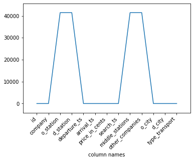

```python
plt.plot(null_df.index, null_df['count'])
plt.xticks(null_df.index, null_df.index, rotation=45,
horizontalalignment='right')
plt.xlabel('column names')
plt.margins(0.1)
plt.show()
```

## Dataset : ticket_data

```python
ticket_data.shape
```

```
(74168, 13)
```

```python
ticket_data.head(15)
```

|  | id | company | o_station | d_station | departure_ts | arrival_ts | price_in_cents | search_ts | middle_stations | other_companies | o_city | d_city | type_transport |
| --- | --- | --- | --- | --- | --- | --- | --- | --- | --- | --- | --- | --- | --- |
| 0 | 6795025 | 8385 | NaN | NaN | 2017-10-13 14:00:00+00 | 2017-10-13 20:10:00+00 | 4550 | 2017-10-01 00:13:31.327+00 | NaN | NaN | 611 | 542 | 2 |
| 1 | 6795026 | 9 | 63.0 | 1044.0 | 2017-10-13 13:05:00+00 | 2017-10-14 06:55:00+00 | 1450 | 2017-10-01 00:13:35.773+00 | {149,418} | {13} | 611 | 542 | 0 |
| 2 | 6795027 | 8377 | 5905.0 | 6495.0 | 2017-10-13 13:27:00+00 | 2017-10-14 21:24:00+00 | 7400 | 2017-10-01 00:13:40.212+00 | {798,798,6794,6246} | {8377,8376} | 611 | 542 | 1 |
| 3 | 6795028 | 8377 | 5905.0 | 6495.0 | 2017-10-13 13:27:00+00 | 2017-10-14 11:02:00+00 | 13500 | 2017-10-01 00:13:40.213+00 | {798,798,6794,6246} | {8377,8376} | 611 | 542 | 1 |
| 4 | 6795029 | 8381 | 5905.0 | 6495.0 | 2017-10-13 21:46:00+00 | 2017-10-14 19:32:00+00 | 7710 | 2017-10-01 00:13:40.213+00 | {5983,5983} | {8380} | 611 | 542 | 1 |
| 5 | 6795030 | 8385 | NaN | NaN | 2017-10-06 05:30:00+00 | 2017-10-06 08:30:00+00 | 1800 | 2017-10-01 01:03:18.948+00 | NaN | NaN | 628 | 453 | 2 |
| 6 | 6795031 | 8385 | NaN | NaN | 2017-10-06 07:00:42+00 | 2017-10-06 09:30:42+00 | 2150 | 2017-10-01 01:03:18.948+00 | NaN | NaN | 628 | 453 | 2 |
| 7 | 6795032 | 8385 | NaN | NaN | 2017-10-06 07:10:00+00 | 2017-10-06 09:40:00+00 | 1700 | 2017-10-01 01:03:18.948+00 | NaN | NaN | 628 | 453 | 2 |
| 8 | 6795033 | 8385 | NaN | NaN | 2017-10-06 10:00:00+00 | 2017-10-06 12:50:00+00 | 1700 | 2017-10-01 01:03:18.948+00 | NaN | NaN | 628 | 453 | 2 |
| 9 | 6795034 | 8385 | NaN | NaN | 2017-10-06 10:00:00+00 | 2017-10-06 12:50:00+00 | 1900 | 2017-10-01 01:03:18.948+00 | NaN | NaN | 628 | 453 | 2 |
| 10 | 6795035 | 8385 | NaN | NaN | 2017-10-06 12:40:00+00 | 2017-10-06 15:40:00+00 | 1550 | 2017-10-01 01:03:18.948+00 | NaN | NaN | 628 | 453 | 2 |
| 11 | 6795036 | 8385 | NaN | NaN | 2017-10-06 13:00:00+00 | 2017-10-06 15:40:00+00 | 1450 | 2017-10-01 01:03:18.948+00 | NaN | NaN | 628 | 453 | 2 |
| 12 | 6795037 | 8385 | NaN | NaN | 2017-10-06 13:00:00+00 | 2017-10-06 15:30:00+00 | 1550 | 2017-10-01 01:03:18.948+00 | NaN | NaN | 628 | 453 | 2 |
| 13 | 6795038 | 8385 | NaN | NaN | 2017-10-06 13:00:00+00 | 2017-10-06 15:30:00+00 | 1550 | 2017-10-01 01:03:18.948+00 | NaN | NaN | 628 | 453 | 2 |
| 14 | 6795039 | 8385 | NaN | NaN | 2017-10-06 13:00:00+00 | 2017-10-06 15:30:00+00 | 1800 | 2017-10-01 01:03:18.95+00 | NaN | NaN | 628 | 453 | 2 |

## Durée

La colonne de la date ne respecte le format timezone qui spécifie 4 chiffres (%z) pour la fonction datetime.

```python
ticket_data.departure_ts = ticket_data.departure_ts+'00'
ticket_data.arrival_ts = ticket_data.arrival_ts+'00'
```

```python
time = []
for i in  range(len(ticket_data)):
    time.append((dt.strptime(ticket_data.arrival_ts[i], '%Y-%m-%d %H:%M:%S%z') - dt.strptime(ticket_data.departure_ts[i], '%Y-%m-%d %H:%M:%S%z')).total_seconds())
```

```python
duree = pd.DataFrame([t/60 for t in time])
```

```python
duree.describe()
```

|  | 0 |
| --- | --- |
| count | 74168.000000 |
| mean | 424.620793 |
| std | 594.981356 |
| min | 20.000000 |
| 25% | 180.000000 |
| 50% | 290.000000 |
| 75% | 480.000000 |
| max | 29571.000000 |

```python
ticket_data["duree"]=duree
```

## Prix moyen

```python
ticket_data.price_in_cents.describe()
```

```
count    74168.000000
mean      4382.711061
std       3739.325367
min        300.000000
25%       1900.000000
50%       3350.000000
75%       5250.000000
max      38550.000000
Name: price_in_cents, dtype: float64
```

## Remplacement

```python
ticket_data.o_station[pd.isna(ticket_data.o_station)] = ticket_data.o_city[pd.isna(ticket_data.o_station)]
```

```python
ticket_data.d_station[pd.isna(ticket_data.d_station)] = ticket_data.d_city[pd.isna(ticket_data.d_station)]
```

```python
ticket_data.isna().sum()
```

```
id                     0
company                0
o_station              0
d_station              0
departure_ts           0
arrival_ts             0
price_in_cents         0
search_ts              0
middle_stations    41441
other_companies    41441
o_city                 0
d_city                 0
type_transport         0
duree                  0
dtype: int64
```

```python
ticket_data.head(10)
```

|  | id | company | o_station | d_station | departure_ts | arrival_ts | price_in_cents | search_ts | middle_stations | other_companies | o_city | d_city | type_transport | duree |
| --- | --- | --- | --- | --- | --- | --- | --- | --- | --- | --- | --- | --- | --- | --- |
| 0 | 6795025 | 8385 | 611.0 | 542.0 | 2017-10-13 14:00:00+0000 | 2017-10-13 20:10:00+0000 | 4550 | 2017-10-01 00:13:31.327+00 | NaN | NaN | 611 | 542 | 2 | 370.0 |
| 1 | 6795026 | 9 | 63.0 | 1044.0 | 2017-10-13 13:05:00+0000 | 2017-10-14 06:55:00+0000 | 1450 | 2017-10-01 00:13:35.773+00 | {149,418} | {13} | 611 | 542 | 0 | 1070.0 |
| 2 | 6795027 | 8377 | 5905.0 | 6495.0 | 2017-10-13 13:27:00+0000 | 2017-10-14 21:24:00+0000 | 7400 | 2017-10-01 00:13:40.212+00 | {798,798,6794,6246} | {8377,8376} | 611 | 542 | 1 | 1917.0 |
| 3 | 6795028 | 8377 | 5905.0 | 6495.0 | 2017-10-13 13:27:00+0000 | 2017-10-14 11:02:00+0000 | 13500 | 2017-10-01 00:13:40.213+00 | {798,798,6794,6246} | {8377,8376} | 611 | 542 | 1 | 1295.0 |
| 4 | 6795029 | 8381 | 5905.0 | 6495.0 | 2017-10-13 21:46:00+0000 | 2017-10-14 19:32:00+0000 | 7710 | 2017-10-01 00:13:40.213+00 | {5983,5983} | {8380} | 611 | 542 | 1 | 1306.0 |
| 5 | 6795030 | 8385 | 628.0 | 453.0 | 2017-10-06 05:30:00+0000 | 2017-10-06 08:30:00+0000 | 1800 | 2017-10-01 01:03:18.948+00 | NaN | NaN | 628 | 453 | 2 | 180.0 |
| 6 | 6795031 | 8385 | 628.0 | 453.0 | 2017-10-06 07:00:42+0000 | 2017-10-06 09:30:42+0000 | 2150 | 2017-10-01 01:03:18.948+00 | NaN | NaN | 628 | 453 | 2 | 150.0 |
| 7 | 6795032 | 8385 | 628.0 | 453.0 | 2017-10-06 07:10:00+0000 | 2017-10-06 09:40:00+0000 | 1700 | 2017-10-01 01:03:18.948+00 | NaN | NaN | 628 | 453 | 2 | 150.0 |
| 8 | 6795033 | 8385 | 628.0 | 453.0 | 2017-10-06 10:00:00+0000 | 2017-10-06 12:50:00+0000 | 1700 | 2017-10-01 01:03:18.948+00 | NaN | NaN | 628 | 453 | 2 | 170.0 |
| 9 | 6795034 | 8385 | 628.0 | 453.0 | 2017-10-06 10:00:00+0000 | 2017-10-06 12:50:00+0000 | 1900 | 2017-10-01 01:03:18.948+00 | NaN | NaN | 628 | 453 | 2 | 170.0 |

## Bonus : Middle station

```python
#ticket_data.middle_stations.apply(replace('{', ''))
tt = ticket_data.middle_stations
ayo = [t for t in tt]
```

```python
ayo = ticket_data.middle_stations
ayo = ayo.fillna('')
```

```python
rb = [set(t.replace('{','').replace('}', '').replace("'", '').split(",")) for t in ayo]
```

```python
[r.clear() if (r=={''}) else r for r in rb];
```

```python
final = [len(i) for i in rb]
ticket_data["final"] = final
```

```python
ticket_data
```

|  | id | company | o_station | d_station | departure_ts | arrival_ts | price_in_cents | search_ts | middle_stations | other_companies | o_city | d_city | type_transport | duree | final |
| --- | --- | --- | --- | --- | --- | --- | --- | --- | --- | --- | --- | --- | --- | --- | --- |
| 0 | 6795025 | 8385 | 611.0 | 542.0 | 2017-10-13 14:00:00+0000 | 2017-10-13 20:10:00+0000 | 4550 | 2017-10-01 00:13:31.327+00 | NaN | NaN | 611 | 542 | 2 | 370.0 | 0 |
| 1 | 6795026 | 9 | 63.0 | 1044.0 | 2017-10-13 13:05:00+0000 | 2017-10-14 06:55:00+0000 | 1450 | 2017-10-01 00:13:35.773+00 | {149,418} | {13} | 611 | 542 | 0 | 1070.0 | 2 |
| 2 | 6795027 | 8377 | 5905.0 | 6495.0 | 2017-10-13 13:27:00+0000 | 2017-10-14 21:24:00+0000 | 7400 | 2017-10-01 00:13:40.212+00 | {798,798,6794,6246} | {8377,8376} | 611 | 542 | 1 | 1917.0 | 3 |
| 3 | 6795028 | 8377 | 5905.0 | 6495.0 | 2017-10-13 13:27:00+0000 | 2017-10-14 11:02:00+0000 | 13500 | 2017-10-01 00:13:40.213+00 | {798,798,6794,6246} | {8377,8376} | 611 | 542 | 1 | 1295.0 | 3 |
| 4 | 6795029 | 8381 | 5905.0 | 6495.0 | 2017-10-13 21:46:00+0000 | 2017-10-14 19:32:00+0000 | 7710 | 2017-10-01 00:13:40.213+00 | {5983,5983} | {8380} | 611 | 542 | 1 | 1306.0 | 1 |
| ... | ... | ... | ... | ... | ... | ... | ... | ... | ... | ... | ... | ... | ... | ... | ... |
| 74163 | 6869182 | 13 | 279.0 | 10729.0 | 2017-10-27 02:30:00+0000 | 2017-10-27 16:00:00+0000 | 2590 | 2017-10-19 10:35:42.943+00 | {408,408} | {8371} | 628 | 562 | 0 | 810.0 | 1 |
| 74164 | 6869185 | 9 | 279.0 | 304.0 | 2017-10-27 07:00:00+0000 | 2017-10-27 13:30:00+0000 | 2700 | 2017-10-19 10:35:42.943+00 | {1105,1105} | {9} | 628 | 562 | 0 | 390.0 | 1 |
| 74165 | 6869187 | 8371 | 10642.0 | 304.0 | 2017-10-27 08:30:00+0000 | 2017-10-27 15:15:00+0000 | 3000 | 2017-10-19 10:35:42.943+00 | {1105,1105} | {9} | 628 | 562 | 0 | 405.0 | 1 |
| 74166 | 6869189 | 13 | 279.0 | 304.0 | 2017-10-27 13:25:00+0000 | 2017-10-27 21:10:00+0000 | 2880 | 2017-10-19 10:35:42.943+00 | {863,863} | {13} | 628 | 562 | 0 | 465.0 | 1 |
| 74167 | 6869191 | 8371 | 10642.0 | 10729.0 | 2017-10-27 14:45:00+0000 | 2017-10-27 21:40:00+0000 | 2000 | 2017-10-19 10:35:42.943+00 | {863,863} | {8371} | 628 | 562 | 0 | 415.0 | 1 |

74168 rows × 15 columns

## Distance

```python
sta = pd.DataFrame(stations[["id","latitude","longitude"]])
dic_sta = sta.set_index('id').T.to_dict('list')
```

```python
cit = pd.DataFrame(cities[["id","latitude","longitude"]])
dic_cit = cit.set_index('id').T.to_dict('list')
```

```python
len(list(set(ticket_data.o_station)))
```

```
662
```

```python
for i in list(set(ticket_data.o_station)):
    print(dic_sta.get(i))
```

[output not shown]

[output cut: 607 more lines]

[output not shown]

```python
o_s = []
for i in range(0,len(ticket_data)):
    o_s.append(dic_sta.get(ticket_data["o_station"][i]))
```

```python
d_s= []
for i in range(0,len(ticket_data)):
    d_s.append(dic_sta.get(ticket_data["d_station"][i]))
```

```python
o_c = []
for i in range(0,len(ticket_data)):
    o_c.append(dic_cit.get(ticket_data["o_city"][i]))
```

```python
d_c = []
for i in range(0,len(ticket_data)):
    d_c.append(dic_cit.get(ticket_data["d_city"][i]))
```

```python
ticket_data.o_station = o_s; ticket_data.d_station= d_s
```

```python
ticket_data.o_city = o_c; ticket_data.d_city = d_c
```

```python
ticket_data.head(20)
```

|  | id | company | o_station | d_station | departure_ts | arrival_ts | price_in_cents | search_ts | middle_stations | other_companies | o_city | d_city | type_transport | duree | final |
| --- | --- | --- | --- | --- | --- | --- | --- | --- | --- | --- | --- | --- | --- | --- | --- |
| 0 | 6795025 | 8385 | [47.07375, 15.416833] | [49.1139678955078, 18.9237194061279] | 2017-10-13 14:00:00+0000 | 2017-10-13 20:10:00+0000 | 4550 | 2017-10-01 00:13:31.327+00 | NaN | NaN | [47.907018, 1.90627] | [43.604452, 3.918318] | 2 | 370.0 | 0 |
| 1 | 6795026 | 9 | [47.896911, 1.854277] | [43.583932, 3.860233] | 2017-10-13 13:05:00+0000 | 2017-10-14 06:55:00+0000 | 1450 | 2017-10-01 00:13:35.773+00 | {149,418} | {13} | [47.907018, 1.90627] | [43.604452, 3.918318] | 0 | 1070.0 | 2 |
| 2 | 6795027 | 8377 | [47.92674, 1.90674] | [43.6049, 3.8805] | 2017-10-13 13:27:00+0000 | 2017-10-14 21:24:00+0000 | 7400 | 2017-10-01 00:13:40.212+00 | {798,798,6794,6246} | {8377,8376} | [47.907018, 1.90627] | [43.604452, 3.918318] | 1 | 1917.0 | 3 |
| 3 | 6795028 | 8377 | [47.92674, 1.90674] | [43.6049, 3.8805] | 2017-10-13 13:27:00+0000 | 2017-10-14 11:02:00+0000 | 13500 | 2017-10-01 00:13:40.213+00 | {798,798,6794,6246} | {8377,8376} | [47.907018, 1.90627] | [43.604452, 3.918318] | 1 | 1295.0 | 3 |
| 4 | 6795029 | 8381 | [47.92674, 1.90674] | [43.6049, 3.8805] | 2017-10-13 21:46:00+0000 | 2017-10-14 19:32:00+0000 | 7710 | 2017-10-01 00:13:40.213+00 | {5983,5983} | {8380} | [47.907018, 1.90627] | [43.604452, 3.918318] | 1 | 1306.0 | 1 |
| 5 | 6795030 | 8385 | [47.677615, 9.314303] | [50.2169342041016, 15.8129949569702] | 2017-10-06 05:30:00+0000 | 2017-10-06 08:30:00+0000 | 1800 | 2017-10-01 01:03:18.948+00 | NaN | NaN | [48.8477019, 2.3523109] | [50.638756, 3.076675] | 2 | 180.0 | 0 |
| 6 | 6795031 | 8385 | [47.677615, 9.314303] | [50.2169342041016, 15.8129949569702] | 2017-10-06 07:00:42+0000 | 2017-10-06 09:30:42+0000 | 2150 | 2017-10-01 01:03:18.948+00 | NaN | NaN | [48.8477019, 2.3523109] | [50.638756, 3.076675] | 2 | 150.0 | 0 |
| 7 | 6795032 | 8385 | [47.677615, 9.314303] | [50.2169342041016, 15.8129949569702] | 2017-10-06 07:10:00+0000 | 2017-10-06 09:40:00+0000 | 1700 | 2017-10-01 01:03:18.948+00 | NaN | NaN | [48.8477019, 2.3523109] | [50.638756, 3.076675] | 2 | 150.0 | 0 |
| 8 | 6795033 | 8385 | [47.677615, 9.314303] | [50.2169342041016, 15.8129949569702] | 2017-10-06 10:00:00+0000 | 2017-10-06 12:50:00+0000 | 1700 | 2017-10-01 01:03:18.948+00 | NaN | NaN | [48.8477019, 2.3523109] | [50.638756, 3.076675] | 2 | 170.0 | 0 |
| 9 | 6795034 | 8385 | [47.677615, 9.314303] | [50.2169342041016, 15.8129949569702] | 2017-10-06 10:00:00+0000 | 2017-10-06 12:50:00+0000 | 1900 | 2017-10-01 01:03:18.948+00 | NaN | NaN | [48.8477019, 2.3523109] | [50.638756, 3.076675] | 2 | 170.0 | 0 |
| 10 | 6795035 | 8385 | [47.677615, 9.314303] | [50.2169342041016, 15.8129949569702] | 2017-10-06 12:40:00+0000 | 2017-10-06 15:40:00+0000 | 1550 | 2017-10-01 01:03:18.948+00 | NaN | NaN | [48.8477019, 2.3523109] | [50.638756, 3.076675] | 2 | 180.0 | 0 |
| 11 | 6795036 | 8385 | [47.677615, 9.314303] | [50.2169342041016, 15.8129949569702] | 2017-10-06 13:00:00+0000 | 2017-10-06 15:40:00+0000 | 1450 | 2017-10-01 01:03:18.948+00 | NaN | NaN | [48.8477019, 2.3523109] | [50.638756, 3.076675] | 2 | 160.0 | 0 |
| 12 | 6795037 | 8385 | [47.677615, 9.314303] | [50.2169342041016, 15.8129949569702] | 2017-10-06 13:00:00+0000 | 2017-10-06 15:30:00+0000 | 1550 | 2017-10-01 01:03:18.948+00 | NaN | NaN | [48.8477019, 2.3523109] | [50.638756, 3.076675] | 2 | 150.0 | 0 |
| 13 | 6795038 | 8385 | [47.677615, 9.314303] | [50.2169342041016, 15.8129949569702] | 2017-10-06 13:00:00+0000 | 2017-10-06 15:30:00+0000 | 1550 | 2017-10-01 01:03:18.948+00 | NaN | NaN | [48.8477019, 2.3523109] | [50.638756, 3.076675] | 2 | 150.0 | 0 |
| 14 | 6795039 | 8385 | [47.677615, 9.314303] | [50.2169342041016, 15.8129949569702] | 2017-10-06 13:00:00+0000 | 2017-10-06 15:30:00+0000 | 1800 | 2017-10-01 01:03:18.95+00 | NaN | NaN | [48.8477019, 2.3523109] | [50.638756, 3.076675] | 2 | 150.0 | 0 |
| 15 | 6795040 | 8385 | [47.677615, 9.314303] | [50.2169342041016, 15.8129949569702] | 2017-10-06 13:40:00+0000 | 2017-10-06 16:30:00+0000 | 1700 | 2017-10-01 01:03:18.95+00 | NaN | NaN | [48.8477019, 2.3523109] | [50.638756, 3.076675] | 2 | 170.0 | 0 |
| 16 | 6795041 | 8385 | [47.677615, 9.314303] | [50.2169342041016, 15.8129949569702] | 2017-10-06 14:00:16+0000 | 2017-10-06 16:30:16+0000 | 1700 | 2017-10-01 01:03:18.95+00 | NaN | NaN | [48.8477019, 2.3523109] | [50.638756, 3.076675] | 2 | 150.0 | 0 |
| 17 | 6795042 | 8385 | [47.677615, 9.314303] | [50.2169342041016, 15.8129949569702] | 2017-10-06 14:00:00+0000 | 2017-10-06 17:00:00+0000 | 1800 | 2017-10-01 01:03:18.95+00 | NaN | NaN | [48.8477019, 2.3523109] | [50.638756, 3.076675] | 2 | 180.0 | 0 |
| 18 | 6795043 | 8385 | [47.677615, 9.314303] | [50.2169342041016, 15.8129949569702] | 2017-10-06 14:00:00+0000 | 2017-10-06 17:20:00+0000 | 1900 | 2017-10-01 01:03:18.95+00 | NaN | NaN | [48.8477019, 2.3523109] | [50.638756, 3.076675] | 2 | 200.0 | 0 |
| 19 | 6795044 | 8385 | [47.677615, 9.314303] | [50.2169342041016, 15.8129949569702] | 2017-10-06 14:00:00+0000 | 2017-10-06 16:40:00+0000 | 2300 | 2017-10-01 01:03:18.95+00 | NaN | NaN | [48.8477019, 2.3523109] | [50.638756, 3.076675] | 2 | 160.0 | 0 |

```python
ticket_data.isna().sum()
```

```
id                     0
company                0
o_station            110
d_station            149
departure_ts           0
arrival_ts             0
price_in_cents         0
search_ts              0
middle_stations    41441
other_companies    41441
o_city                 0
d_city                 0
type_transport         0
duree                  0
final                  0
dtype: int64
```

```python
ticket_data.isna().sum()
```

```
id                     0
company                0
o_station            110
d_station            149
departure_ts           0
arrival_ts             0
price_in_cents         0
search_ts              0
middle_stations    41441
other_companies    41441
o_city                 0
d_city                 0
type_transport         0
duree                  0
final                  0
dtype: int64
```

```python
ticket_data = ticket_data.drop(['middle_stations','other_companies'], axis=1).dropna()
```

```python
ticket_data.isna().sum()
```

```
id                0
company           0
o_station         0
d_station         0
departure_ts      0
arrival_ts        0
price_in_cents    0
search_ts         0
o_city            0
d_city            0
type_transport    0
duree             0
final             0
dtype: int64
```

```python
ticket_data.shape
```

```
(73909, 13)
```

```python
ticket_data = ticket_data.reset_index(drop=True);
ticket_data
```

|  | id | company | o_station | d_station | departure_ts | arrival_ts | price_in_cents | search_ts | o_city | d_city | type_transport | duree | final |
| --- | --- | --- | --- | --- | --- | --- | --- | --- | --- | --- | --- | --- | --- |
| 0 | 6795025 | 8385 | [47.07375, 15.416833] | [49.1139678955078, 18.9237194061279] | 2017-10-13 14:00:00+0000 | 2017-10-13 20:10:00+0000 | 4550 | 2017-10-01 00:13:31.327+00 | [47.907018, 1.90627] | [43.604452, 3.918318] | 2 | 370.0 | 0 |
| 1 | 6795026 | 9 | [47.896911, 1.854277] | [43.583932, 3.860233] | 2017-10-13 13:05:00+0000 | 2017-10-14 06:55:00+0000 | 1450 | 2017-10-01 00:13:35.773+00 | [47.907018, 1.90627] | [43.604452, 3.918318] | 0 | 1070.0 | 2 |
| 2 | 6795027 | 8377 | [47.92674, 1.90674] | [43.6049, 3.8805] | 2017-10-13 13:27:00+0000 | 2017-10-14 21:24:00+0000 | 7400 | 2017-10-01 00:13:40.212+00 | [47.907018, 1.90627] | [43.604452, 3.918318] | 1 | 1917.0 | 3 |
| 3 | 6795028 | 8377 | [47.92674, 1.90674] | [43.6049, 3.8805] | 2017-10-13 13:27:00+0000 | 2017-10-14 11:02:00+0000 | 13500 | 2017-10-01 00:13:40.213+00 | [47.907018, 1.90627] | [43.604452, 3.918318] | 1 | 1295.0 | 3 |
| 4 | 6795029 | 8381 | [47.92674, 1.90674] | [43.6049, 3.8805] | 2017-10-13 21:46:00+0000 | 2017-10-14 19:32:00+0000 | 7710 | 2017-10-01 00:13:40.213+00 | [47.907018, 1.90627] | [43.604452, 3.918318] | 1 | 1306.0 | 1 |
| ... | ... | ... | ... | ... | ... | ... | ... | ... | ... | ... | ... | ... | ... |
| 73904 | 6869182 | 13 | [48.838424, 2.382411] | [47.212922, -1.551565] | 2017-10-27 02:30:00+0000 | 2017-10-27 16:00:00+0000 | 2590 | 2017-10-19 10:35:42.943+00 | [48.8477019, 2.3523109] | [47.248785, -1.520898] | 0 | 810.0 | 1 |
| 73905 | 6869185 | 9 | [48.838424, 2.382411] | [47.248785, -1.520898] | 2017-10-27 07:00:00+0000 | 2017-10-27 13:30:00+0000 | 2700 | 2017-10-19 10:35:42.943+00 | [48.8477019, 2.3523109] | [47.248785, -1.520898] | 0 | 390.0 | 1 |
| 73906 | 6869187 | 8371 | [48.865601, 2.414588] | [47.248785, -1.520898] | 2017-10-27 08:30:00+0000 | 2017-10-27 15:15:00+0000 | 3000 | 2017-10-19 10:35:42.943+00 | [48.8477019, 2.3523109] | [47.248785, -1.520898] | 0 | 405.0 | 1 |
| 73907 | 6869189 | 13 | [48.838424, 2.382411] | [47.248785, -1.520898] | 2017-10-27 13:25:00+0000 | 2017-10-27 21:10:00+0000 | 2880 | 2017-10-19 10:35:42.943+00 | [48.8477019, 2.3523109] | [47.248785, -1.520898] | 0 | 465.0 | 1 |
| 73908 | 6869191 | 8371 | [48.865601, 2.414588] | [47.212922, -1.551565] | 2017-10-27 14:45:00+0000 | 2017-10-27 21:40:00+0000 | 2000 | 2017-10-19 10:35:42.943+00 | [48.8477019, 2.3523109] | [47.248785, -1.520898] | 0 | 415.0 | 1 |

73909 rows × 13 columns

```python
ko = []
for i in range(0,len(ticket_data)):
    ko.append(haversine( (ticket_data.o_station[i][0] , ticket_data.o_station[i][1]), (ticket_data.d_station[i][0] , ticket_data.d_station[i][1] ), Unit.KILOMETERS))
```

```python
pd.DataFrame(ko).describe()
```

|  | 0 |
| --- | --- |
| count | 73909.000000 |
| mean | 534.335689 |
| std | 278.549857 |
| min | 16.570498 |
| 25% | 379.429205 |
| 50% | 503.463856 |
| 75% | 658.138688 |
| max | 2148.431835 |

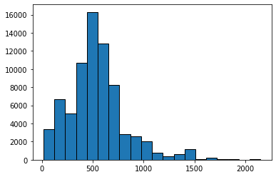

```python
plt.hist(ko,edgecolor='black', linewidth=1, density=False, bins=20);
```

```python
i = 0
haversine( (ticket_data.o_station[i][0] , ticket_data.o_station[i][1]), (ticket_data.d_station[i][0] , ticket_data.d_station[i][1] ), Unit.KILOMETERS)
```

```
345.334328642377
```

```python
tab=[]
for i in ko:
    if(i<=200):
        tab.append(0)
    elif((i>=201) & (i<=800)):
        tab.append(1)
    elif((i>=801) & (i<=2000)):
        tab.append(2)
    else:
        tab.append(3)
```

```python
len(tab)
```

```
73909
```

```python
ticket_data["alias"]=tab
```

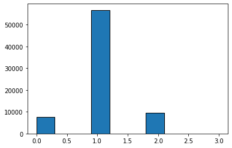

```python
plt.hist(ticket_data["alias"], edgecolor='black', linewidth=1, density=False, bins=10);
```

```python
(ticket_data["alias"] == 3).sum()
```

```
72
```

```python
pd.to_datetime(ticket_data.search_ts)
```

```
0       2017-10-01 00:13:31.327000+00:00
1       2017-10-01 00:13:35.773000+00:00
2       2017-10-01 00:13:40.212000+00:00
3       2017-10-01 00:13:40.213000+00:00
4       2017-10-01 00:13:40.213000+00:00
                      ...
73904   2017-10-19 10:35:42.943000+00:00
73905   2017-10-19 10:35:42.943000+00:00
73906   2017-10-19 10:35:42.943000+00:00
73907   2017-10-19 10:35:42.943000+00:00
73908   2017-10-19 10:35:42.943000+00:00
Name: search_ts, Length: 73909, dtype: datetime64[ns, UTC]
```

```python
import re
a = [re.sub(r"(?=\.)(.*?)(?=\+)",'', str(t)) for t in ticket_data.search_ts]
```

```python
a[0]
```

```
'2017-10-01 00:13:31+00'
```

```python
ticket_data.search_ts = a
ticket_data.search_ts = ticket_data.search_ts+'00'
```

```python
planning = []
for i in  range(len(ticket_data)):
    planning.append((dt.strptime(ticket_data.departure_ts[i], '%Y-%m-%d %H:%M:%S%z') - dt.strptime(ticket_data.search_ts[i], '%Y-%m-%d %H:%M:%S%z')).total_seconds())
```

```python
planning = pd.DataFrame([t/60 for t in planning])
```

```python
ticket_data["planning"] = planning
```

```python
ticket_data
```

|  | id | company | o_station | d_station | departure_ts | arrival_ts | price_in_cents | search_ts | o_city | d_city | type_transport | duree | final | alias | planning |
| --- | --- | --- | --- | --- | --- | --- | --- | --- | --- | --- | --- | --- | --- | --- | --- |
| 0 | 6795025 | 8385 | [47.07375, 15.416833] | [49.1139678955078, 18.9237194061279] | 2017-10-13 14:00:00+0000 | 2017-10-13 20:10:00+0000 | 4550 | 2017-10-01 00:13:31+0000 | [47.907018, 1.90627] | [43.604452, 3.918318] | 2 | 370.0 | 0 | 1 | 18106.483333 |
| 1 | 6795026 | 9 | [47.896911, 1.854277] | [43.583932, 3.860233] | 2017-10-13 13:05:00+0000 | 2017-10-14 06:55:00+0000 | 1450 | 2017-10-01 00:13:35+0000 | [47.907018, 1.90627] | [43.604452, 3.918318] | 0 | 1070.0 | 2 | 1 | 18051.416667 |
| 2 | 6795027 | 8377 | [47.92674, 1.90674] | [43.6049, 3.8805] | 2017-10-13 13:27:00+0000 | 2017-10-14 21:24:00+0000 | 7400 | 2017-10-01 00:13:40+0000 | [47.907018, 1.90627] | [43.604452, 3.918318] | 1 | 1917.0 | 3 | 1 | 18073.333333 |
| 3 | 6795028 | 8377 | [47.92674, 1.90674] | [43.6049, 3.8805] | 2017-10-13 13:27:00+0000 | 2017-10-14 11:02:00+0000 | 13500 | 2017-10-01 00:13:40+0000 | [47.907018, 1.90627] | [43.604452, 3.918318] | 1 | 1295.0 | 3 | 1 | 18073.333333 |
| 4 | 6795029 | 8381 | [47.92674, 1.90674] | [43.6049, 3.8805] | 2017-10-13 21:46:00+0000 | 2017-10-14 19:32:00+0000 | 7710 | 2017-10-01 00:13:40+0000 | [47.907018, 1.90627] | [43.604452, 3.918318] | 1 | 1306.0 | 1 | 1 | 18572.333333 |
| ... | ... | ... | ... | ... | ... | ... | ... | ... | ... | ... | ... | ... | ... | ... | ... |
| 73904 | 6869182 | 13 | [48.838424, 2.382411] | [47.212922, -1.551565] | 2017-10-27 02:30:00+0000 | 2017-10-27 16:00:00+0000 | 2590 | 2017-10-19 10:35:42+0000 | [48.8477019, 2.3523109] | [47.248785, -1.520898] | 0 | 810.0 | 1 | 1 | 11034.300000 |
| 73905 | 6869185 | 9 | [48.838424, 2.382411] | [47.248785, -1.520898] | 2017-10-27 07:00:00+0000 | 2017-10-27 13:30:00+0000 | 2700 | 2017-10-19 10:35:42+0000 | [48.8477019, 2.3523109] | [47.248785, -1.520898] | 0 | 390.0 | 1 | 1 | 11304.300000 |
| 73906 | 6869187 | 8371 | [48.865601, 2.414588] | [47.248785, -1.520898] | 2017-10-27 08:30:00+0000 | 2017-10-27 15:15:00+0000 | 3000 | 2017-10-19 10:35:42+0000 | [48.8477019, 2.3523109] | [47.248785, -1.520898] | 0 | 405.0 | 1 | 1 | 11394.300000 |
| 73907 | 6869189 | 13 | [48.838424, 2.382411] | [47.248785, -1.520898] | 2017-10-27 13:25:00+0000 | 2017-10-27 21:10:00+0000 | 2880 | 2017-10-19 10:35:42+0000 | [48.8477019, 2.3523109] | [47.248785, -1.520898] | 0 | 465.0 | 1 | 1 | 11689.300000 |
| 73908 | 6869191 | 8371 | [48.865601, 2.414588] | [47.212922, -1.551565] | 2017-10-27 14:45:00+0000 | 2017-10-27 21:40:00+0000 | 2000 | 2017-10-19 10:35:42+0000 | [48.8477019, 2.3523109] | [47.248785, -1.520898] | 0 | 415.0 | 1 | 1 | 11769.300000 |

73909 rows × 15 columns

### Dataframe des colonnes d'intérêt

```python
df = ticket_data[["id","price_in_cents","type_transport","duree","final","alias","planning"]]
```

```python
df
```

|  | id | price_in_cents | type_transport | duree | final | alias | planning |
| --- | --- | --- | --- | --- | --- | --- | --- |
| 0 | 6795025 | 4550 | 2 | 370.0 | 0 | 1 | 18106.483333 |
| 1 | 6795026 | 1450 | 0 | 1070.0 | 2 | 1 | 18051.416667 |
| 2 | 6795027 | 7400 | 1 | 1917.0 | 3 | 1 | 18073.333333 |
| 3 | 6795028 | 13500 | 1 | 1295.0 | 3 | 1 | 18073.333333 |
| 4 | 6795029 | 7710 | 1 | 1306.0 | 1 | 1 | 18572.333333 |
| ... | ... | ... | ... | ... | ... | ... | ... |
| 73904 | 6869182 | 2590 | 0 | 810.0 | 1 | 1 | 11034.300000 |
| 73905 | 6869185 | 2700 | 0 | 390.0 | 1 | 1 | 11304.300000 |
| 73906 | 6869187 | 3000 | 0 | 405.0 | 1 | 1 | 11394.300000 |
| 73907 | 6869189 | 2880 | 0 | 465.0 | 1 | 1 | 11689.300000 |
| 73908 | 6869191 | 2000 | 0 | 415.0 | 1 | 1 | 11769.300000 |

73909 rows × 7 columns

```python
df.corr()
```

|  | id | price_in_cents | type_transport | duree | final | alias | planning |
| --- | --- | --- | --- | --- | --- | --- | --- |
| id | 1.000000 | 0.135449 | -0.069254 | 0.078047 | 0.095404 | 0.050708 | 0.026932 |
| price_in_cents | 0.135449 | 1.000000 | -0.268135 | 0.158508 | 0.504438 | 0.007478 | 0.081610 |
| type_transport | -0.069254 | -0.268135 | 1.000000 | -0.421016 | -0.800345 | 0.154486 | -0.358573 |
| duree | 0.078047 | 0.158508 | -0.421016 | 1.000000 | 0.334825 | 0.021912 | 0.266460 |
| final | 0.095404 | 0.504438 | -0.800345 | 0.334825 | 1.000000 | -0.149103 | 0.254549 |
| alias | 0.050708 | 0.007478 | 0.154486 | 0.021912 | -0.149103 | 1.000000 | 0.023935 |
| planning | 0.026932 | 0.081610 | -0.358573 | 0.266460 | 0.254549 | 0.023935 | 1.000000 |

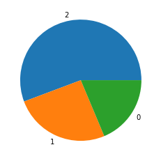

```python
effectif = ticket_data.type_transport.value_counts()
plt.pie(effectif,labels=effectif.index)

plt.show()
```

### Suggestion

```python
# select=[]
# #ex : 6869187
# while True:
#     try:
#         temp = int(input("Enter the temperature of the hour: "))
#     except ValueError:
#         print('Value must be a number.')
#     else:
#         if temp in ticket_data["id"].values:
#             select=ticket_data[ticket_data.id == temp]
#             break
#         else:
#             print('Value must be between -50 and 130')
```

```python
# ticket_data[ticket_data.id == 6869187]
```

```python
# start = select.iloc[0,2];
# end = select.iloc[0,3]
```

```python
# fig = gmaps.figure()
# trajet = gmaps.directions_layer(
#         start, end)
# fig.add_layer(trajet)
# fig
```